# Predicting Post-High School Outcomes

Jordan and Kristen’s project

Revised project introduction.

Kristen Beamer , Jordan Peeples  
2021-03-03

### Question of Interest

We are interested in studying the determinants of students’ post high school outcomes. We will begin by asking questions about which factors lead a student to pursue post-secondary education. Subsequently, we would like to better understand determinants that influence a student to attend a 2-year or technical college versus a traditional 4-year school. Are these decisions more related to individual characteristics or school fixed effects, or is there another underlying factor? How do student expectations compare to their actual outcomes?

Conditional on attending a traditional 4-year school, we want to determine the factors that may prompt a student to pursue a STEM major.

### Data

In order to analyze these questions, we utilize public-use data from the United States High School Longitudinal Study from 2009-2013 (HSLS:09). This is a rich data set comprised of parent, teacher, school counselor, and student surveys. HSLS:09 also holds information on schools included in the sample.

HSLS:09 provides important variables that influence students post-high school trajectories. Some information contained include courses taken by the student and the frequency and subject matter of meetings with school counselors. In addition, the restricted-use version of HSLS:09 contains standardized testing scores by student, such as scores on the PSAT, SAT, or AP exams (if the student took the test). Even without testing, the rich nature of the public-use HSLS:09 should provide ample information to unpack determinants of educational attainment.

Another interesting lens of the HSLS:09 survey is that it tracks students’ educational goals over their high school career. Starting in 9th grade, the students are asked about their plans after high school, and this can be directly compared to their true post-high school outcomes. Since there is an abundance of information within HSLS:09, the work so far has been wrangling the 6,000+ different variables that exist within the data.

The first step is to load the data. We rename it for easier code interpretability.

```r
#import
urlSchool <- url("https://www.dropbox.com/s/bzoyhrtj3gi4t1t/36423-0001-Data.rda?raw=1")
urlStudent <- url("https://www.dropbox.com/s/x26tsp84rcn48gj/36423-0002-Data.rda?raw=1")
load(urlSchool)
load(urlStudent)
# rename
schoolData <- da36423.0001
studentData <- da36423.0002
```

Given that HSLS:09 holds over 6,000 variables, we will start our examination of the data by selecting just student interview questions. In later iterations of this project we will select other surveys, such as the survey for parents, teachers, or counselors. In this chunk of code we drop variables that have been suppressed for public use, and rename some complicated categorical variables.

```r
studentDataStudents <- studentData %>%
  select(X3TCREDENG:S1TALKFUTURE, S3FOCUS) %>%
  mutate_all(na_if, -5) %>%
  mutate_all(na_if, -4) %>%
  mutate_all(na_if, -7) %>%
  mutate_all(na_if, -8) %>%
  mutate_all(na_if, -9) %>%
  mutate(S1EDUEXPECT = recode(S1EDUEXPECT, "(01) Less than high school" = "Less than HS",
                              "(02) High school diploma or GED" = "HS Diploma/GED",
                              "(03) Start an Associate's degree" = "Start Assoc.",
                              "(04) Complete an Associate's degree" = "Complete Assoc.",
                              "(05) Start a Bachelor's degree" = "Start Bachelor's",
                              "(06) Complete a Bachelor's degree" = "Complete Bachelor's",
                              "(07) Start a Master's degree" = "Start Master's",
                              "(08) Complete a Master's degree" = "Complete Master's",
                              "(09) Start Ph.D/M.D/Law/other prof degree" = "Start PhD",
                              "(10) Complete Ph.D/M.D/Law/other prof degree" = "Complete PhD",
                              "(11) Don't know" = "Don't know")) %>%
  mutate(S3FOCUS = recode(S3FOCUS, "(1) Taking classes from postsecondary institution" = "Postsecondary",
                          "(2) Participating in an apprenticeship program" = "Apprenticeship",
                          "(3) Working for pay" = "Work",
                          "(4) Serving in the military" = "Military",
                          "(5) Starting family or taking care of your/his/her children" = "Childcare",
                          "(6) Attending high school or homeschool" = "Continued school",
                          "(7) Taking course to prepare for the GED/other high school equivalency exam" = "GED Prep",
                          "(8) Equally focused on more than one of these" = "Multiple"))
studentDataStudents <- studentDataStudents[ , colSums(is.na(studentDataStudents)) < 12000]
```

These steps drop the student data from 6,608 to 365 variables over 23,503 observations. This will be a much easier place to begin unpacking the wealth of information within the data.

### Summary Statistics

Now, with our cleaned subset of the HSLS:09 data, we can examine preliminary summary statistics on our main dependent variable of interest.

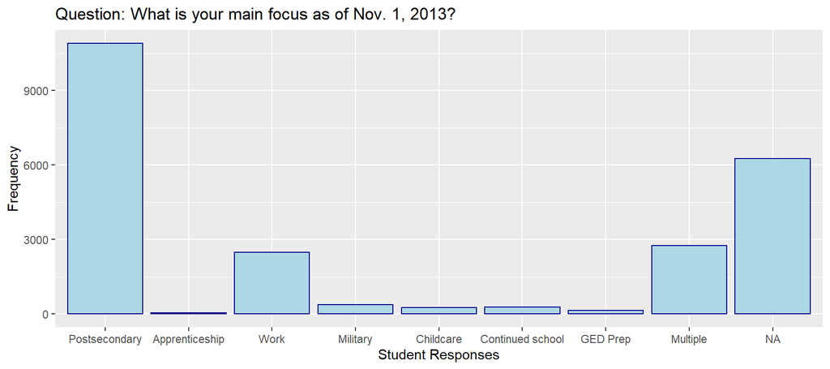

```r
  ggplot(data=studentDataStudents, aes(x=S3FOCUS)) +geom_bar(color="darkblue", fill="lightblue") +
    labs(title="Question: What is your main focus as of Nov. 1, 2013?",
         x="Student Responses",
         y="Frequency")
```

### Models

In order to approach these questions, we will begin by growing trees for each of our questions as stated above. It will be important to utilize appropriate cross-validation and tuning in order to properly characterize the underlying mechanisms at play. We are currently determining which chunk of variables to focus on, as a classification tree is computationally heavier than a regression tree. We have already estimated an initial tree as practice on the student interview only. We want to clean the data in a way that avoids repetitive variables and includes possible important ones.

### References

United States Department of Education. Institute of Education Sciences. National Center for Education Statistics. High School Longitudinal Study, 2009-2013 [United States]. Inter-university Consortium for Political and Social Research [distributor], 2016-05-12. https://doi.org/10.3886/ICPSR36423.v1